# Notebook: Explore Datasets

In order to gain a better understanding of what the data collected looks like, important characteristics of the dataset will be presented/visualised.

## Load Packages

```r
library(ggplot2)
library(dplyr)
source("get_weather_data.R")
```

## Code

### Load Datasets

First, we need to load the dataset and add some columns that will be used for exploring the dataset

```r
# Load departure data
departure_data <- read.csv("../datasets/departure_dataset.csv")
weather_data <- read.csv("../datasets/weather_munich_dataset.csv")
```

For better data handling, I will convert the columns with time data to POSIXct

```r
departure_data$departure_scheduled_datetime_local <- as.POSIXct(departure_data$departure_scheduled_datetime_local)
weather_data$six_hours_starting_from_datatime <- as.POSIXct(paste(weather_data$date, weather_data$six_hours_starting_from))
```

Add weather data to departure dataset (using the script from get_weather_data.R)

```r
departure_data$six_hours_starting_from_datatime <- as.POSIXct(sapply(departure_data$departure_scheduled_datetime_local, get_weather_data))
```

Exclude unnecessary columns that we don’t want to add to the departure_data

```r
merge_cols_weather_data <- setdiff(names(weather_data), c("date", "six_hours_starting_from"))
departure_data <- merge(departure_data, weather_data[, c(merge_cols_weather_data)], by.x = "six_hours_starting_from_datatime", by.y = "six_hours_starting_from_datatime", all.x = TRUE)
head(departure_data)
```

```
##   six_hours_starting_from_datatime departure_scheduled_datetime_local
## 1              2017-10-01 00:00:00                2017-10-01 05:50:00
## 2              2017-10-01 00:00:00                2017-10-01 05:50:00
## 3              2017-10-01 00:00:00                2017-10-01 05:50:00
## 4              2017-10-01 00:00:00                2017-10-01 05:50:00
## 5              2017-10-01 00:00:00                2017-10-01 05:55:00
## 6              2017-10-01 06:00:00                2017-10-01 06:05:00
##   departure_scheduled_time_local_timezone departure_scheduled_datetime_utc
## 1                                    CEST                 2017-10-01 03:50
## 2                                    CEST                 2017-10-01 03:50
## 3                                    CEST                 2017-10-01 03:50
## 4                                    CEST                 2017-10-01 03:50
## 5                                    CEST                 2017-10-01 03:55
## 6                                    CEST                 2017-10-01 04:05
##   flight_status airline_name flight_number flight_number_IATA airline_code
```

[output cut: 62 more lines]

### Explore Overall Departure Data

In a first step, we can explore the dataset and its characteristics. For every analysis, it’s important to keep in mind, that the dataset is only a radnom sample as I only collected data for four random hours of each day (see 01_… notebooks). For each day between 01.10.2017 and 31.05.2023 flights that took off in Munich were collected from flightera.org. Now, we can have a look at how many flights have landed, were diverted etc. (occurrences of the various flight statuses)

```r
table(departure_data$flight_status)
```

```
##
## Cancelled  Diverted    Landed      Live   Unknown
##      3765       555    179231        60      5172
```

Due to the Covid-19 pandemic, strong differences between the years can be observed here.

```r
flight_status_count <- departure_data %>%
  group_by(departure_scheduled_year_local, departure_scheduled_month_local, flight_status) %>%
  summarise(count = n())
```

[output not shown]

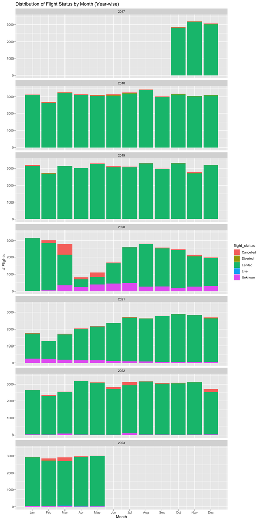

```r
month_labels <- c("Jan", "Feb", "Mar", "Apr", "May", "Jun", "Jul", "Aug", "Sep", "Oct", "Nov", "Dec")

ggplot(flight_status_count, aes(x = departure_scheduled_month_local, y = count, fill = flight_status)) +
  geom_bar(stat = "identity", position = "stack") +
  facet_wrap(~departure_scheduled_year_local, ncol = 1) +
  xlab("Month") +
  ylab("# Flights") +
  ggtitle("Distribution of Flight Status by Month (Year-wise)") +
  scale_x_continuous(breaks = 1:12, labels = month_labels)
```

Next, we can look at how many flights were *planned* to take off in the period for which the data was collected for. Here it can be seen that in 2020, the year that was strongly influenced by the pandemic, there was a decrease in the amount of flights.

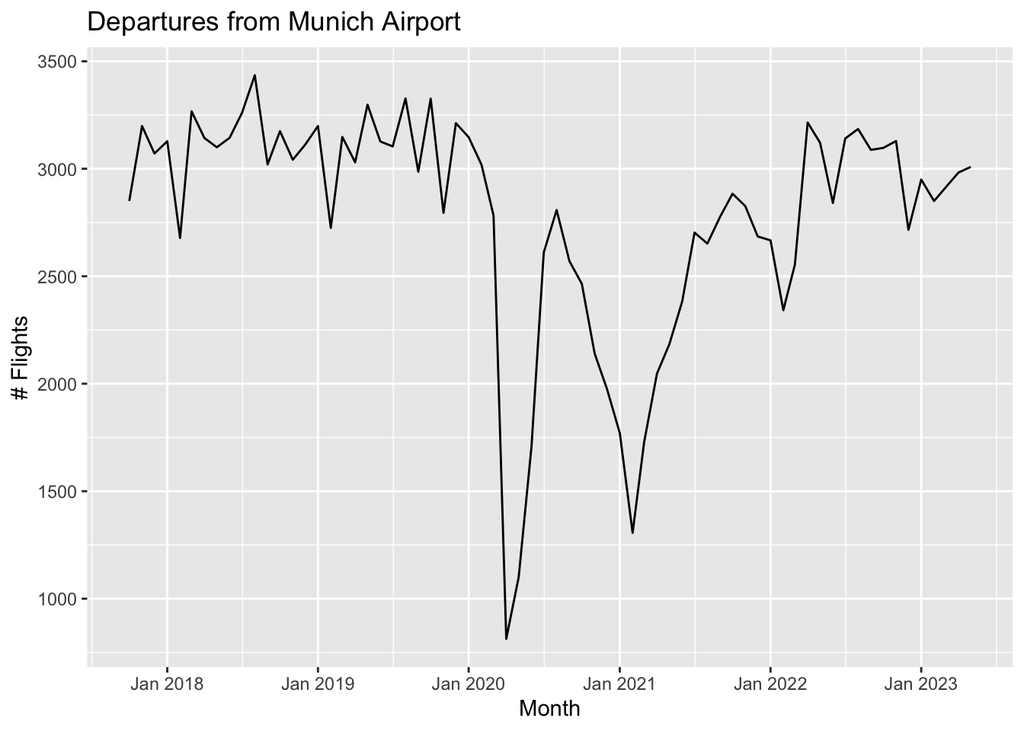

```r
flight_count_departure <- departure_data %>%
  group_by(departure_scheduled_month_year_local) %>%
  summarise(count = n())

ggplot(flight_count_departure, aes(x = as.Date(paste(departure_scheduled_month_year_local, "01", sep = "-")), y = count)) +
  geom_line() +
  scale_x_date(date_labels = "%b %Y", date_breaks = "1 year") +
  labs(x = "Month", y = "# Flights") +
  ggtitle("Departures from Munich Airport")
```

Next, we can look at which airline’s flights are most frequently scheduled to take off from Munich.

```r
airlines <- departure_data %>%
  group_by(airline_name) %>%
  summarise(count = n()) %>%
  arrange(-count)

head(airlines, n=20)
```

```
## # A tibble: 20 × 2
##    airline_name              count
##    <chr>                     <int>
##  1 Lufthansa                108455
##  2 Eurowings                  9651
##  3 Air Dolomiti               6118
##  4 Condor                     4917
##  5 TUIfly                     4734
##  6 KLM Royal Dutch Airlines   3109
##  7 easyJet                    2906
##  8 SunExpress                 2404
##  9 British Airways            2321
## 10 Air France                 2277
## 11 TAP - Air Portugal         1995
## 12 Turkish Airlines           1845
## 13 Austrian Airlines          1809
## 14 LOT - Polish Airlines      1601
## 15 Aegean Airlines            1571
## 16 Iberia                     1380
## 17 ASL Airlines Belgium       1375
## 18 Croatia Airlines           1324
## 19 bmi Regional               1165
## 20 Air Baltic                 1149
```

Of course, this can also be displayed in a bar chart with the percentage share of each airline in the overall dataset. This might be better to show the strong differences between the airlines.

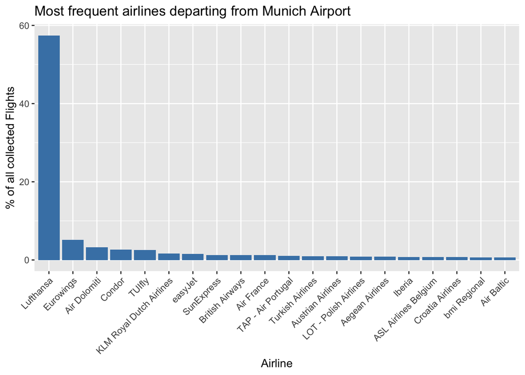

```r
top_20_airlines_departure <- departure_data %>%
  count(airline_name) %>%
  mutate(percentage = (n / nrow(departure_data)) * 100) %>%
  arrange(-percentage) %>%
  head(20)

ggplot(top_20_airlines_departure, aes(x = reorder(airline_name, -percentage), y = percentage)) +
  geom_bar(stat = "identity", fill = "steelblue") +
  labs(x = "Airline", y = "% of all collected Flights", title = "Most frequent airlines departing from Munich Airport") +
  theme(axis.text.x = element_text(angle = 45, hjust = 1))
```

You can also look at which airports are the most frequent destinations among flights departing from Munich

```r
destinations <- departure_data %>%
  group_by(destination_IATA, destination_name) %>%
  summarise(count = n()) %>%
  arrange(-count)
head(destinations, n=20)
```

```
## # A tibble: 20 × 3
## # Groups:   destination_IATA [20]
##    destination_IATA destination_name  count
##    <chr>            <chr>             <int>
##  1 HAM              Hamburg            8678
##  2 FRA              Frankfurt          7895
##  3 DUS              Dusseldorf         7696
##  4 AMS              Amsterdam          5539
##  5 TXL              Berlin             5325
##  6 CGN              Cologne            4796
##  7 CDG              Paris              4717
##  8 LHR              London             4523
##  9 MAD              Madrid             3387
## 10 PMI              Palma de Mallorca  3366
## 11 HAJ              Hannover           3225
## 12 BRU              Brussels           2833
## 13 CPH              Copenhagen         2813
## 14 FCO              Rome               2801
## 15 VIE              Vienna             2788
## 16 BCN              Barcelona          2777
## 17 BER              Berlin             2717
## 18 ATH              Athens             2613
## 19 LIS              Lisbon             2610
## 20 WAW              Warsaw             2581
```

… or by country

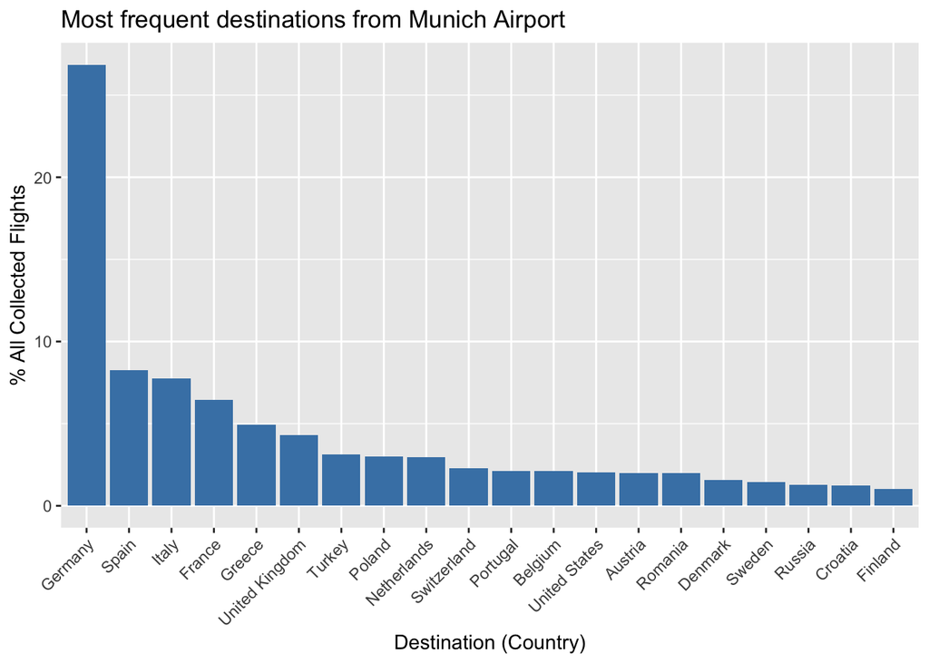

```r
top_20_destinations_departure <- departure_data %>%
  count(destination_country) %>%
  mutate(percentage = (n / nrow(departure_data)) * 100) %>%
  arrange(-percentage) %>%
  head(20)

ggplot(top_20_destinations_departure, aes(x = reorder(destination_country, -percentage), y = percentage)) +
  geom_bar(stat = "identity", fill = "steelblue") +
  labs(x = "Destination (Country)", y = "% All Collected Flights", title = "Most frequent destinations from Munich Airport") +
  # by changing the angle of the labels by 45° it's much easier to read them
  theme(axis.text.x = element_text(angle = 45, hjust = 1))
```

### Feature Exploration / Prediction Target

Next, I can look at which columns are possible predictors.

```r
delay_departure_data <- departure_data
```

```r
delay_departure_data$departure_scheduled_datetime_local <- as.Date(delay_departure_data$departure_scheduled_datetime_local)
```

Next, we can examine how often and how much delayed flights are taking off from Munich. To analyse delays, we only look at flights that have landed and not flights that have been cancelled, diverted or whose status is unknown etc.. We also need to remove outliers. There seem to be flights with extreme delays, which probably does not correspond to reality but might be due to technical issues.

```r
z_scores <- scale(delay_departure_data$delay_departure_min)
z_threshold <- 3
outliers <- abs(z_scores) > z_threshold
outlier_data <- delay_departure_data[outliers, ]
delay_departure_data <- delay_departure_data[!outliers, ]

# Among the collected flights there were some with more than one day of delay (>1440 minutes)
head(outlier_data[order(-outlier_data$delay_departure_min), ])[, c("delay_departure_min", "departure_scheduled_datetime_utc", "destination_name")]
```

```
##        delay_departure_min departure_scheduled_datetime_utc  destination_name
## 69958                 2128                 2019-08-16 04:05 Palma de Mallorca
## 153038                1560                 2022-06-02 17:45            London
## 167767                1530                 2022-10-27 07:55             Paris
## 187206                1501                 2023-05-15 15:00         Frankfurt
## 184791                1482                 2023-04-21 05:15             Paris
## 185924                1477                 2023-05-02 13:25          Helsinki
```

```r
delay_departure_data <- delay_departure_data[delay_departure_data$flight_status == "Landed", ]
```

#### Prediction target

Between the 0.2 and the 0.8 quantile the slope is fairly constant, while between the 0.8 and the 1.0 quantile, one can see a clear increase. Between the 0.0 and the 0.2 quantile, the slope is at 0 for some time, which can be explained by the fact that many flights have exactly 0 minutes delay.

```r
summary(delay_departure_data$delay_departure_min)
```

```
##    Min. 1st Qu.  Median    Mean 3rd Qu.    Max.
## -116.00    5.00   13.00   17.35   23.00  157.00
```

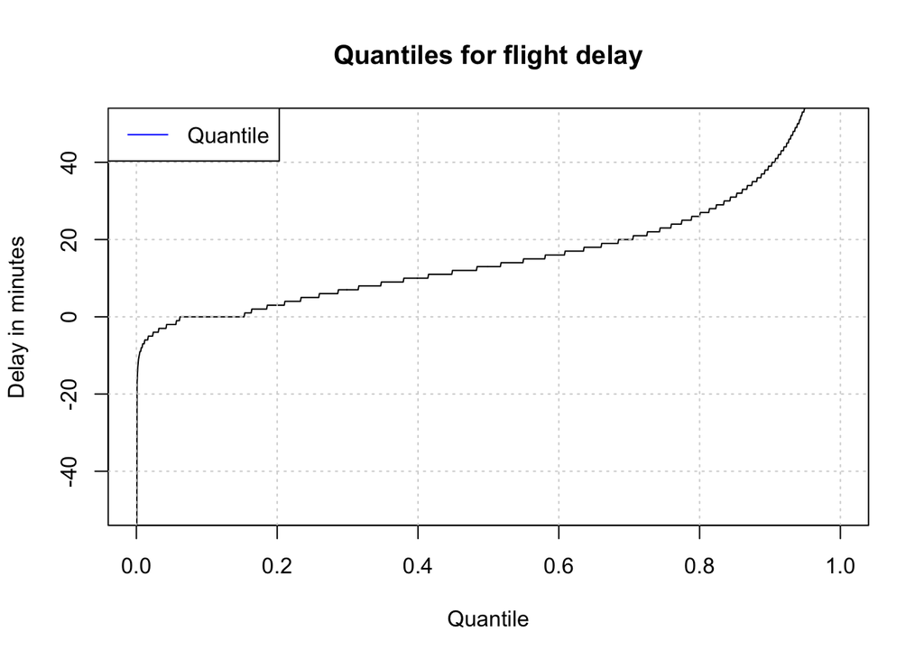

```r
step <- 0.001
category_quantiles <- quantile(delay_departure_data$delay_departure_min, probs = seq(0, 1, by = step))
plot(seq(0, 1, by = step), category_quantiles, type = "l",
     xlab = "Quantile", ylab = "Delay in minutes",
     main = "Quantiles for flight delay",
      ylim = c(-50, 50)
    )

grid()
legend("topleft", legend = "Quantile", lty = 1, col = "blue")
```

The goal will eventually be to predict whether a flight has…

- no or little delay
- a long or very long delay

I decided to split these two groups based on the median. Further notes on the prediction task can also be found in notebook 04.

```r
quantiles <- quantile(delay_departure_data$delay_departure_min, probs = c(0.0, 0.5, 1.0))
quantiles
```

```
##   0%  50% 100%
## -116   13  157
```